# Packages required for the course

2019-08-07

# Knit this R Markdown

Before class, make sure this RMarkdown file knits cleanly, which installs and checks for the required packages covered in class. Installation of some packages will require answering prompted questions, so run the document interactively prior to trying to knit.

## Required R packages

```r
cran_req_packages <- c("Seurat",
                       "BiocManager",
                       "tidyverse",
                       "devtools",
                       "clustree"
                       )

bioc_req_packages <- c("M3Drop",
                       "scRecover",
                       "destiny",
                       "slingshot",
                       "fgsea",
                       "DelayedMatrixStats",
                       "scran"
                      )

git_req_packages <- c("rnabioco/clustifyr",
                      "immunogenomics/harmony",
                      "quon-titative-biology/scAlign",
                      "cole-trapnell-lab/monocle3"
                     )
```

## Check R version

```r
if (!(as.numeric(R.Version()$major) >= 3 & as.numeric(R.Version()$minor >= 6))) {
  error("please install latest version of R")
}
```

## Try to install packages

```r
options(pkgType="binary")
installed_packages <- rownames(installed.packages())

# here are the packages not yet installed
cran_download <- setdiff(cran_req_packages, installed_packages)
bioc_download <- setdiff(bioc_req_packages, installed_packages)
git_download <- git_req_packages[!basename(git_req_packages) %in% installed_packages]

# cran packages are installed with command `install.packages`
for (pack in cran_download) {
  install.packages(pack,repos = "http://cran.us.r-project.org")
}

# bioconductor packages are installed with command `BiocManager::install`
for (pack in bioc_download) {
  BiocManager::install(pack)
}

# github packages are installed with command `devtools::install_github`
for (pack in git_download) {
  devtools::install_github(pack)
}
```

## check that R packages installed

```r
required_pkgs <- c(cran_req_packages,
                   bioc_req_packages,
                   basename(git_req_packages))

installed <- required_pkgs %in% installed.packages()

if (all(!installed)) {
  missing_pkgs <- required_pkgs[!installed]
  stop(paste0(missing_pkgs, " not installed, please retry installation\n"))
}
```

# Install python dependencies

`Seurat` and `Monocle3` use the R package `reticulate` to call some python modules. Follow the instructions below to install these packages using reticulate.

## Check python version

```r
library(reticulate)

py_info <- py_discover_config()

if (py_info$version < 3.5){
  err <- c("please install at least python 3.5",
           "If you do not have python3 installed",
           "we recommend using conda to install python3",
           "go to https://conda.io/en/latest/miniconda.html",
           "and install python 3.7 (64 bit) using the ",
           ".pkg installer for MacOS, .exe for Windows, or bash installer for linux")
  stop(paste0(err, sep = "\n"))
}

py_info
```

```
## python:         /home/rmsheridan/.virtualenvs/r-reticulate/bin/python
## libpython:      /usr/lib/python3.6/config-3.6m-x86_64-linux-gnu/libpython3.6.so
## pythonhome:     /usr:/usr
## version:        3.6.8 (default, Jan 14 2019, 11:02:34)  [GCC 8.0.1 20180414 (experimental) [trunk revision 259383]]
## numpy:          /home/rmsheridan/.local/lib/python3.6/site-packages/numpy
## numpy_version:  1.17.0
##
## python versions found:
##  /home/rmsheridan/.virtualenvs/r-reticulate/bin/python
##  /usr/bin/python
##  /usr/bin/python3
```

```r
modules_fullname <- c("umap-learn", "louvain", "virtualenv", "cellbrowser")
modules_shortname <- c("umap", "louvain", "virtualenv", "cellbrowser")

modules_needed <- modules_fullname[!sapply( modules_shortname, py_module_available)]

for(module in modules_needed) {
  py_install(module, method = "auto")
}
```

```
## Using virtual environment '~/.virtualenvs/r-reticulate' ...
```

## Test python dependencies

```r
library(Seurat)
```

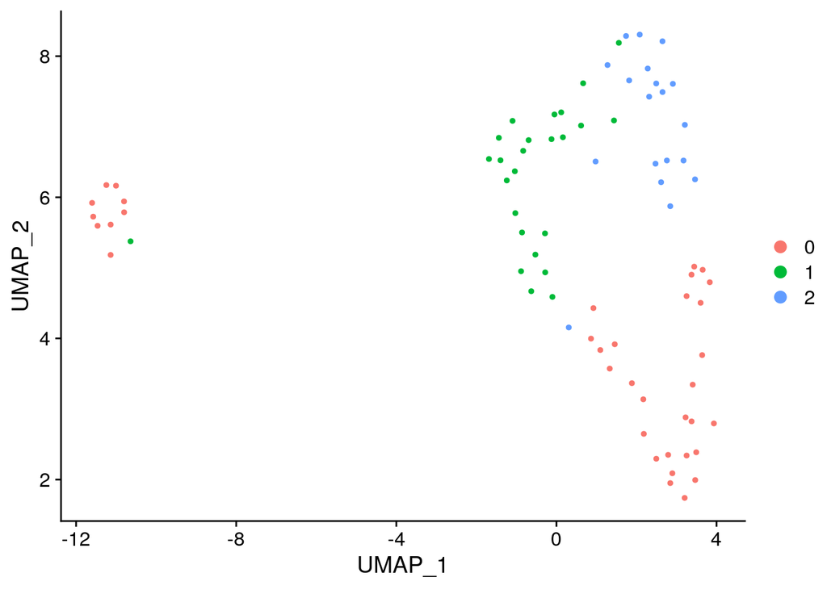

```r
data(pbmc_small)
pbmc_small <- RunUMAP(object = pbmc_small, dims = 1:5)
p <- DimPlot(pbmc_small, reduction = "umap")
p
```

```r
library(monocle3)
dat <- load_a549()
dat <- preprocess_cds(dat, num_dim = 10)
dat <- reduce_dimension(dat)

res <- tryCatch(cluster_cells(dat),
                error=function(e) e,
                warning=function(w) w)

if(is(res, "error")){
  stop(dat$message,
       "\nerror with calling cluster_cells from Monocle")
}
```

# Common issues with R package installs:

## Required linux packages:

Linux users may need to install libssl-dev, libcurl4-openssl-dev, libgsl-dev, libgdal-dev, libudunits2-dev, and libxml2-dev (using apt, pacman, etc.) to successfully install these packages in R. Package names may differ by linux distribution.

## Missing xcode (or compilers):

If you are on MacOS and get an error such as this:

```
xcode-select: note: no developer tools were found at '/Applications/Xcode.app', requesting install. Choose an option in the dialog to download the command line developer tools.
ERROR: compilation failed for package 'XXX'
```

You need to download the command line tools for xcode. To do this open up the Terminal.app and execute:

```
xcode-select --install
```

Click install when prompted.

Alternatively RStudio may also prompt you to install these tools when you are trying to install the packages.

Restart R after install and try to install the packages again.

## Issues with installing the python packages

## Try using pip

In terminal execute:

```
pip install umap-learn
pip install louvain
```

## Try using conda

In terminal execute:

```
conda install -c conda-forge umap-learn
conda install louvain
```

Double check that the version of python that `reticulate` is using is the same as the one that you are installing the packages into.

```r
library(reticulate)
py_config()

# To change python version e.g. to /usr/bin/python3

use_python("/usr/bin/python3", required = TRUE)

# or set a environmental variable from R
Sys.setenv(RETICULATE_PYTHON = "/usr/bin/python3")
```

```r
# pip python version
Sys.which("pip")
```